## IOE 460 - Decision Analysis

## 1 - Introduction to IOE 460

## Wednesday 13 September, 9am

# Objectives

This assignment is focussed on reintroducing you to some of the pre-requisite knowledge expected in the course and introduce you to Python programming and the Jupyter notebook if you are unfamiliar with it.

## Submission

You are expected to submit this as a pdf online. Use a Jupyter notebook and show your working by doing calculations in the python box. Simply go File -> Print preview then print to pdf - I know it's not perfect/pretty, they're working on it. Your submission should not have your name on it or any identifying information.

## 1 Optimization

The effect of $d$ kilograms of fertiliser, $0 < d < 1000$ on the expected yield $\lambda$ of a crop is given by $\lambda = 25(4+\sqrt(d))$. The cost of a kilogram of fertiliser is \$10 and the profit from a unit of crop is \$20. Find the expected maximum value (EMV) decision rule - aka, what is the solution that optimizes profit?

## 2 - Intro to python

To assign a variable in python we say

```python
x = 3
```

By assigning a variable we can then use it later. Unlike in algebra, we have associated a number or object with that variable. This allows us to do the following calculations

```python
2 + x
```

```
5
```

```python
x**2
```

```
9
```

etc.

You can assign more than just an integer to a variable in python. You can assign any object, such as a list of numbers, or a string (like 'hi') etc.

### 2.1

A coin toss is essentially a random choice between 0 and 1. To simulate a coin toss we can use

```python
import numpy as np
np.random.randint(0,2) # note that low = 0, high = 2, but the values returned will be 0 or 1
# because it is a random integer on the interval [0,2)
```

```
1
```

We can simulate multiple coin tosses by using the `size` optional input. For example

```python
np.random.randint(0, 2, size = 2)
```

```
array([1, 0])
```

Provide code that calculates the number of heads following tossing a coin twice.

### 2.2

Now we want to determine the *expected number of heads when tossing a coin twice* We will simulate this 1000 times. Run the following code, understand it, and include it and the resulting figures in your jupyter homework

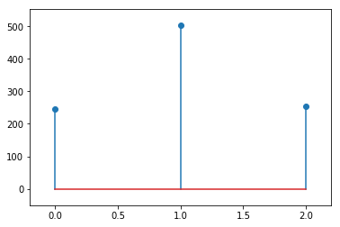

```python
import numpy as np
import matplotlib.pyplot as plt

num_sim = 1000
heads = np.zeros(num_sim, dtype = int) # here I'm creating an empty list where we will insert the number for heads from each pair of tosses
for i in range(num_sim):
    heads[i] = np.random.randint(low = 0, high = 2, size = 2).sum()
plt.stem(np.bincount(heads), marker = 'o')
plt.margins(0.1)
plt.show()
```

## 3 - Monte Carlo Simulation

### 3.1

What is the mean and variance of a $ X \sim N(\mu = 10,\sigma = 2) $

### 3.2

Generate 10 random numbers from a Normal distribution $ X \sim N(\mu = 10,\sigma = 2) $ This code will be useful to you

```
import numpy as np
n_sim = 10
data = np.random.normal(loc = 0, scale = 1, size = n_sim)
```

What is the mean and standard deviation of this random sample? Plot a histogram of the sample. The following code will be useful to you

```
import matplotlib.pyplot as plt
plt.hist(data)
plt.show()
```

### 3.3

Generate 1000 random numbers from a Normal distribution $ X \sim N(\mu = 10,\sigma = 2) $ What is the mean and standard deviation of this random sample? Plot a histogram of the sample.

### 3.4

What is the central limit theorem? In particular, comment on how the normal distribution is relevant.

## 4 Expectation

The decision maker (DM) is in charge of manufacturing T-shirts in aid of a sponsored marathon race in 50 weeks time. Leasing a small machine for manufacturing these (decision $d1$) will cost \$100,000 whilst leasing a large machine (decision $d2$) will cost \$300,000 over these 50 weeks. If DM leases the large machine, she may obtain free TV advertising with probability $p$. If this happens she expects to sell 1,800 items a week. Without free advertising she expects to sell only 400 a week. If DM makes \$10 profit for each T-shirt sold, show that her best decision is to to buy the smaller machine if $p < \dfrac{2}{7}$.

## 5 - Case Study

From Clemen and Reilly *"Making hard decisions"* Note: There are no "right" answers to this. I want you to read, think about, and discuss your thoughts in the answer.  
No more than half a page of text.

[figure not shown]

Created with Jupyter, by Tom Logan. Copyright © 2017